# 24133064_NguyenThiKieuTrang_LAB6

2026-05-25

```r
sales <- read.csv("sales_raw.csv")
# view(sales)

students <- read.csv("students.csv")
# view(students)

banks <- read.csv("bank_raw.csv")
# view(banks)
```

# I. Những yêu cầu chung

## 1. Xử lý dữ liệu nhiễu

## Sinh viên phải kiểm tra và xử lý các dạng nhiễu sau:

• Mã định danh không thống nhất, ví dụ cùng một kiểu mã nhưng khác số lượng ký tự,sai dấu phân tách hoặc viết hoa/viết thường không đồng nhất.

• Tên nhóm hoặc nhãn phân loại bị trùng nghĩa nhưng khác cách viết, ví dụ HCM,HoChiMinh, TPHCM.

• Cột số bị lưu ở dạng chuỗi, có chứa ký tự thừa như dấu phẩy, khoảng trắng hoặc ký hiệu tiền tệ.

• Dòng dữ liệu lặp hoàn toàn hoặc lặp một phần theo khóa chính nghiệp vụ.

• Nhiễu do nhập sai đơn vị, ví dụ doanh thu theo nghìn ở một số dòng và theo đơn vị gốc ở các dòng khác.

Yêu cầu sinh viên mô tả rõ cách phát hiện, quy tắc làm sạch và lý do lựa chọn giữ, sửa hoặc loại bỏ từng nhóm bản ghi.

## 2. Xử lý missing values

Ngoài việc đếm số lượng NA, sinh viên cần:

• Phân biệt missing values tường minh và missing values ngầm định bằng complete() hoặc thao tác pivot phù hợp.

• Phân tích missing theo nhóm, ví dụ missing tập trung ở một khu vực, một thời điểm hay một danh mục sản phẩm.

• Đề xuất ít nhất 3 chiến lược xử lý: loại bỏ, nội suy/điền giá trị, hoặc giữ nguyên để cảnh báo rủi ro.

• So sánh ảnh hưởng của từng chiến lược tới thống kê mô tả và biểu đồ.

• Với dữ liệu chuỗi thời gian doanh thu, thử điền giá trị thiếu bằng forward fill,backward fill hoặc trung bình trượt, sau đó nhận xét tác động.

## 3. Xử lý giá trị bất thường

Sinh viên cần phát hiện outlier bằng nhiều cách thay vì chỉ dùng trực quan hóa:

• Quy tắc miền giá trị hợp lệ theo ngữ cảnh nghiệp vụ, ví dụ doanh thu âm là không hợp lệ, số đơn hàng bằng 0 có thể hợp lệ hoặc không tùy bối cảnh.

• Quy tắc IQR với boxplot để phát hiện giá trị lệch mạnh.

• Kiểm tra outlier theo từng nhóm thay vì toàn bộ dữ liệu, ví dụ doanh thu theo từng khu vực hoặc từng nhóm sản phẩm.

• Phân biệt outlier thật và lỗi nhập liệu.

Sinh viên phải tạo ít nhất 3 phiên bản dữ liệu:

1. Giữ nguyên outlier.
2. Loại bỏ outlier.
3. Chuyển outlier thành NA rồi xử lý tiếp.

Sau đó so sánh các thống kê và biểu đồ giữa ba phiên bản.

# II. Yêu cầu với từng tập dữ liệu

## 1. Dữ liệu Sales

## Làm sạch dữ liệu

### Chuẩn hóa product_code và region khi xuất hiện nhiều biến thể cách viết.

```r
names(sales)
```

```
## [1] "product_code" "region"       "X2022_Q1"     "X2022_Q2"     "X2023_Q1"
## [6] "X2023_Q2"
```

```r
sales <- sales%>%
  mutate(
    product_code=toupper(product_code),
    product_code=str_replace_all(product_code,"-_ ",""),
    region=case_when(
      region %in% c("HoChiMinh","TPHCM","tp hcm")~"HCM",
      TRUE~region
    )
    )
unique(sales$product_code)
```

```
## [1] "ELEC-TV"   "ELEC-LAP"  "HOME-VAC"  "FASH-SHOE"
```

```r
unique(sales$region)
```

```
## [1] "HCM" "HN"  "DN"
```

### Phát hiện các dòng có doanh thu tăng/giảm đột ngột bất thường giữa các quý.

```r
sales <- sales %>%
  mutate(
    change_Q1_Q2 = X2022_Q2 - X2022_Q1,
    change_Q2_Q3 = X2023_Q1 - X2022_Q2,
    change_Q3_Q4 = X2023_Q2 - X2023_Q1
  )

head(sales)
```

```
##   product_code region X2022_Q1 X2022_Q2 X2023_Q1 X2023_Q2 change_Q1_Q2
## 1      ELEC-TV    HCM      120      135      160      175           15
## 2      ELEC-TV     HN       95      100      110      120            5
## 3      ELEC-TV     DN        0      105      115      130          105
## 4     ELEC-LAP    HCM      210      220      260      280           10
## 5     ELEC-LAP     HN      180      190      210     9999           10
## 6     HOME-VAC    HCM       75       80       90       95            5
##   change_Q2_Q3 change_Q3_Q4
## 1           25           15
## 2           10           10
## 3           10           15
## 4           40           20
## 5           20         9789
## 6           10            5
```

#### Dòng có doanh thu tăng/giảm đột ngột bất thường

```r
sales <- sales %>%
  mutate(
    abnormal = ifelse(
      abs(change_Q1_Q2) > 500 |
      abs(change_Q2_Q3) > 500 |
      abs(change_Q3_Q4) > 500,
      "Bat thuong",
      "Binh thuong"
    )
  )

sales %>%
  filter(abnormal == "Bat thuong")
```

```
##   product_code region X2022_Q1 X2022_Q2 X2023_Q1 X2023_Q2 change_Q1_Q2
## 1     ELEC-LAP     HN      180      190      210     9999           10
## 2    FASH-SHOE     DN      128      999      160      180          871
## 3    FASH-SHOE     DN      128      999      160      180          871
##   change_Q2_Q3 change_Q3_Q4   abnormal
## 1           20         9789 Bat thuong
## 2         -839           20 Bat thuong
## 3         -839           20 Bat thuong
```

### Kiểm tra xem giá trị cực lớn là outlier thật do mùa vụ hay lỗi nhập liệu.

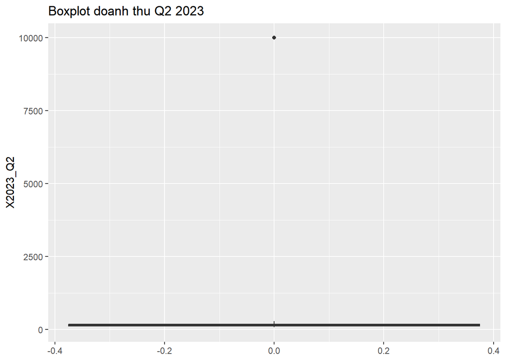

```r
ggplot(sales, aes(y = X2023_Q2)) +
  geom_boxplot() +
  ggtitle("Boxplot doanh thu Q2 2023")
```

### Tạo biến tăng trưởng theo quý và đánh dấu các điểm gãy xu hướng.

```r
sales <- sales %>%
  mutate(
    trend_break=ifelse(
      abs(change_Q1_Q2)>0.5|
      abs(change_Q2_Q3)>0.5|
      abs(change_Q3_Q4)>0.5,
      "Diem gay xu huong",
      "Binh thuong"
    ))
trend_data <- sales %>%
  filter(trend_break == "Diem gay xu huong")

trend_data
```

```
##    product_code region X2022_Q1 X2022_Q2 X2023_Q1 X2023_Q2 change_Q1_Q2
## 1       ELEC-TV    HCM      120      135      160      175           15
## 2       ELEC-TV     HN       95      100      110      120            5
## 3       ELEC-TV     DN        0      105      115      130          105
## 4      ELEC-LAP    HCM      210      220      260      280           10
## 5      ELEC-LAP     HN      180      190      210     9999           10
## 6      HOME-VAC    HCM       75       80       90       95            5
## 7      HOME-VAC     HN       60       NA       70       75           NA
## 8      HOME-VAC     HN       60       NA       70       75           NA
## 9     FASH-SHOE    HCM      140      150      170      190           10
## 10    FASH-SHOE     HN      130      140      155      165           10
## 11    FASH-SHOE     DN      128      999      160      180          871
## 12    FASH-SHOE     DN      128      999      160      180          871
##    change_Q2_Q3 change_Q3_Q4    abnormal       trend_break
## 1            25           15 Binh thuong Diem gay xu huong
## 2            10           10 Binh thuong Diem gay xu huong
## 3            10           15 Binh thuong Diem gay xu huong
## 4            40           20 Binh thuong Diem gay xu huong
## 5            20         9789  Bat thuong Diem gay xu huong
## 6            10            5 Binh thuong Diem gay xu huong
## 7            NA            5        <NA> Diem gay xu huong
## 8            NA            5        <NA> Diem gay xu huong
## 9            20           20 Binh thuong Diem gay xu huong
## 10           15           10 Binh thuong Diem gay xu huong
## 11         -839           20  Bat thuong Diem gay xu huong
## 12         -839           20  Bat thuong Diem gay xu huong
```

### Kiểm tra trùng lặp theo khóa product_code + region + quarter.

```r
duplicated_rows <- sales %>%
  group_by(product_code, region) %>%
  filter(n() > 1)

duplicated_rows
```

```
## # A tibble: 4 × 11
## # Groups:   product_code, region [2]
##   product_code region X2022_Q1 X2022_Q2 X2023_Q1 X2023_Q2 change_Q1_Q2
##   <chr>        <chr>     <int>    <int>    <int>    <int>        <int>
## 1 HOME-VAC     HN           60       NA       70       75           NA
## 2 HOME-VAC     HN           60       NA       70       75           NA
## 3 FASH-SHOE    DN          128      999      160      180          871
## 4 FASH-SHOE    DN          128      999      160      180          871
## # ℹ 4 more variables: change_Q2_Q3 <int>, change_Q3_Q4 <int>, abnormal <chr>,
## #   trend_break <chr>
```

## Xử lý và trực quan dữ liệu

## Một chuỗi bán lẻ muốn dự báo doanh thu quý tiếp theo cho từng nhóm hàng và từng khu vực để lập kế hoạch nhập hàng, phân bổ ngân sách marketing và tối ưu tồn kho.

## Yêu cầu:

### 1. Chuyển dữ liệu về long format theo quý.

```r
sales_long <- sales %>%
  select(product_code, region,
         X2022_Q1, X2022_Q2,
         X2023_Q1, X2023_Q2) %>%

  pivot_longer(
    cols = c(X2022_Q1, X2022_Q2,
             X2023_Q1, X2023_Q2),

    names_to = "quarter",
    values_to = "revenue"
  )

sales_long
```

```
## # A tibble: 48 × 4
##    product_code region quarter  revenue
##    <chr>        <chr>  <chr>      <int>
##  1 ELEC-TV      HCM    X2022_Q1     120
##  2 ELEC-TV      HCM    X2022_Q2     135
##  3 ELEC-TV      HCM    X2023_Q1     160
##  4 ELEC-TV      HCM    X2023_Q2     175
##  5 ELEC-TV      HN     X2022_Q1      95
##  6 ELEC-TV      HN     X2022_Q2     100
##  7 ELEC-TV      HN     X2023_Q1     110
##  8 ELEC-TV      HN     X2023_Q2     120
##  9 ELEC-TV      DN     X2022_Q1       0
## 10 ELEC-TV      DN     X2022_Q2     105
## # ℹ 38 more rows
```

### 2. Xây dựng chuỗi thời gian doanh thu theo region, group và item.

```r
sales_time <- sales_long %>%
  arrange(region, product_code, quarter)

sales_time
```

```
## # A tibble: 48 × 4
##    product_code region quarter  revenue
##    <chr>        <chr>  <chr>      <int>
##  1 ELEC-TV      DN     X2022_Q1       0
##  2 ELEC-TV      DN     X2022_Q2     105
##  3 ELEC-TV      DN     X2023_Q1     115
##  4 ELEC-TV      DN     X2023_Q2     130
##  5 FASH-SHOE    DN     X2022_Q1     128
##  6 FASH-SHOE    DN     X2022_Q1     128
##  7 FASH-SHOE    DN     X2022_Q2     999
##  8 FASH-SHOE    DN     X2022_Q2     999
##  9 FASH-SHOE    DN     X2023_Q1     160
## 10 FASH-SHOE    DN     X2023_Q1     160
## # ℹ 38 more rows
```

### 3. Tạo các đặc trưng: doanh thu quý trước, tốc độ tăng trưởng, trung bình trượt 2 quý,xu hướng theo năm.

```r
sales_feature <- sales_time %>%
  group_by(region, product_code) %>%
  mutate(
    prev_revenue = lag(revenue),
    growth_rate = (revenue - prev_revenue) / prev_revenue,
    moving_avg_2q = (revenue + prev_revenue) / 2,
    year = ifelse(grepl("2022", quarter), 2022, 2023)
  ) %>%
  ungroup()

sales_feature
```

```
## # A tibble: 48 × 8
##    product_code region quarter  revenue prev_revenue growth_rate moving_avg_2q
##    <chr>        <chr>  <chr>      <int>        <int>       <dbl>         <dbl>
##  1 ELEC-TV      DN     X2022_Q1       0           NA     NA               NA
##  2 ELEC-TV      DN     X2022_Q2     105            0    Inf               52.5
##  3 ELEC-TV      DN     X2023_Q1     115          105      0.0952         110
##  4 ELEC-TV      DN     X2023_Q2     130          115      0.130          122.
##  5 FASH-SHOE    DN     X2022_Q1     128           NA     NA               NA
##  6 FASH-SHOE    DN     X2022_Q1     128          128      0              128
##  7 FASH-SHOE    DN     X2022_Q2     999          128      6.80           564.
##  8 FASH-SHOE    DN     X2022_Q2     999          999      0              999
##  9 FASH-SHOE    DN     X2023_Q1     160          999     -0.840          580.
## 10 FASH-SHOE    DN     X2023_Q1     160          160      0              160
## # ℹ 38 more rows
## # ℹ 1 more variable: year <dbl>
```

### 4. Xây dựng ít nhất 2 cách dự báo: phương pháp đơn giản dựa trên trung bình/trend và một mô hình hồi quy tuyến tính hoặc mô hình chuỗi thời gian cơ bản.

#### 4. Dự báo cách 1: Trung bình 2 quý gần nhất

```r
forecast_avg <- sales_feature %>%
  group_by(region, product_code) %>%
  summarise(
    forecast_next_quarter = mean(tail(revenue, 2), na.rm = TRUE),
    .groups = "drop"
  )

forecast_avg
```

```
## # A tibble: 10 × 3
##    region product_code forecast_next_quarter
##    <chr>  <chr>                        <dbl>
##  1 DN     ELEC-TV                      122.
##  2 DN     FASH-SHOE                    180
##  3 HCM    ELEC-LAP                     270
##  4 HCM    ELEC-TV                      168.
##  5 HCM    FASH-SHOE                    180
##  6 HCM    HOME-VAC                      92.5
##  7 HN     ELEC-LAP                    5104.
##  8 HN     ELEC-TV                      115
##  9 HN     FASH-SHOE                    160
## 10 HN     HOME-VAC                      75
```

#### 4. Dự báo cách 2: Hồi quy tuyến tính đơn giản

```r
sales_model <- sales_feature %>%
  mutate(time_index = case_when(
    quarter == "X2022_Q1" ~ 1,
    quarter == "X2022_Q2" ~ 2,
    quarter == "X2023_Q1" ~ 3,
    quarter == "X2023_Q2" ~ 4
  ))

model <- lm(revenue ~ time_index, data = sales_model)

forecast_lm <- data.frame(time_index = 5)

predict(model, forecast_lm)
```

```
##        1
## 988.8333
```

### 5. Vẽ đồ thi trực quan hóa dữ liệu theo doanh thu

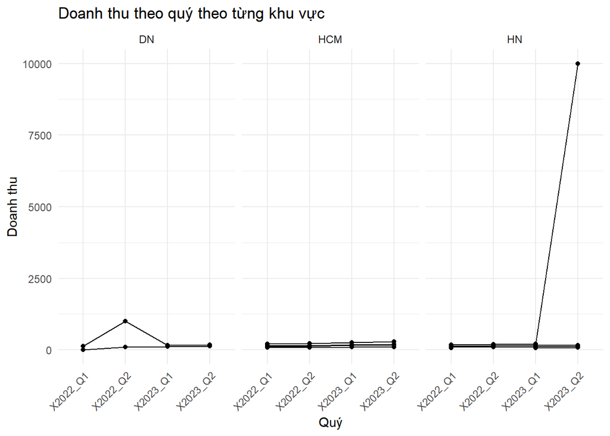

```r
ggplot(sales_long, aes(x = quarter, y = revenue, group = product_code)) +
  geom_line() +
  geom_point() +
  facet_wrap(~ region) +
  labs(
    title = "Doanh thu theo quý theo từng khu vực",
    x = "Quý",
    y = "Doanh thu"
  )+
  theme_minimal() +
  theme(
    axis.text.x = element_text(angle = 45, vjust = 1, hjust = 1)
  )
```

#### Trước khi làm sạch

```r
summary(sales_long$revenue)
```

```
##    Min. 1st Qu.  Median    Mean 3rd Qu.    Max.     NAs
##    0.00   96.25  137.50  387.78  180.00 9999.00       2
```

Trước làm sạch (Raw Data): Mô hình dự báo sẽ bị các điểm nhiễu làm “lệch hướng”, dẫn đến việc dự báo tương lai quá cao hoặc quá thấp (sai số lớn).

#### Sau khi làm sạch

```r
sales_clean <- sales_long %>%
  mutate(
    revenue=ifelse(revenue==9999,NA,revenue)
  )
summary(sales_clean$revenue)
```

```
##    Min. 1st Qu.  Median    Mean 3rd Qu.    Max.     NAs
##     0.0    95.0   135.0   174.2   180.0   999.0       3
```

### 7. Nếu dùng dữ liệu chưa làm sạch để dự báo thì rủi ro quản trị là gì?

Nếu sử dụng dữ liệu chưa làm sạch để dự báo, các giá trị bất thường như 9999 có thể làm sai lệch kết quả dự báo. Điều này khiến doanh nghiệp nhập hàng quá nhiều hoặc quá ít, phân bổ ngân sách marketing không hợp lý và làm tăng rủi ro tồn kho hoặc thiếu hàng. Vì vậy, cần làm sạch dữ liệu trước khi xây dựng mô hình dự báo.

## 2. Dữ liệu student

## Làm sạch dữ liệu

### Kiểm tra điểm vượt ngoài miền hợp lệ, ví dụ nhỏ hơn 0 hoặc lớn hơn 10.

```r
students_score_clean <- students %>%
  filter(!(sem1_score>10|sem1_score<0|sem2_score>10|sem2_score<0))
students_score_clean
```

```
##   class_id student_name sem1_score sem2_score attendance
## 1   CS01-A           An        7.5        7.8         92
## 2   CS01-A                     7.2        7.6         83
## 3   CS02-B          Chi        6.2        6.8         78
## 4   CS02-B         Dung        7.1        7.4         88
## 5   IT01-A          Huy        8.4        8.7         95
## 6   IT01-A          Lan        9.0        9.2         97
## 7   IT01-A         Minh        2.0       10.0        101
## 8   IT01-A         Minh        2.0       10.0        101
```

### Kiểm tra chuyên cần vượt 100 hoặc âm.

```r
student_attendance_clean <- students%>%
  filter(!(attendance>100|attendance<0))
student_attendance_clean
```

```
##   class_id student_name sem1_score sem2_score attendance
## 1   CS01-A           An        7.5        7.8         92
## 2   CS01-A         Binh        8.0         NA         85
## 3   CS01-A                     7.2        7.6         83
## 4   CS02-B          Chi        6.2        6.8         78
## 5   CS02-B         Dung        7.1        7.4         88
## 6   IT01-A          Huy        8.4        8.7         95
## 7   IT01-A          Lan        9.0        9.2         97
## 8   IT02-C        Trang       11.0        9.5         90
```

### Xử lý tên sinh viên bị thiếu hoặc trùng không hợp lệ.

```r
student_name_clean <- students %>%
  drop_na(student_name)%>%
  distinct(student_name,.keep_all = TRUE)
student_name_clean
```

```
##   class_id student_name sem1_score sem2_score attendance
## 1   CS01-A           An        7.5        7.8         92
## 2   CS01-A         Binh        8.0         NA         85
## 3   CS01-A                     7.2        7.6         83
## 4   CS02-B          Chi        6.2        6.8         78
## 5   CS02-B         Dung        7.1        7.4         88
## 6   IT01-A          Huy        8.4        8.7         95
## 7   IT01-A          Lan        9.0        9.2         97
## 8   IT01-A         Minh        2.0       10.0        101
## 9   IT02-C        Trang       11.0        9.5         90
```

### Phát hiện lớp có số quan sát quá ít hoặc cấu trúc mã lớp không đúng mẫu.

```r
class_id_clean <- students %>%
  group_by(class_id)%>%
  mutate(so_luong=n())%>%
  ungroup()%>%
  filter(!str_detect(class_id,"^[A-Z]{2}[0-9]{2}-[A-Z]$")| so_luong<3)
class_id_clean
```

```
## # A tibble: 3 × 6
##   class_id student_name sem1_score sem2_score attendance so_luong
##   <chr>    <chr>             <dbl>      <dbl>      <int>    <int>
## 1 CS02-B   Chi                 6.2        6.8         78        2
## 2 CS02-B   Dung                7.1        7.4         88        2
## 3 IT02-C   Trang              11          9.5         90        1
```

## Trực quan hóa dữ liệu để:

### Dự báo số sinh viên đạt chuẩn đầu ra hoặc dự báo tỷ lệ học lại theo lớp/học kỳ. Bài toán này giúp sinh viên hiểu cùng một quy trình làm sạch có thể phục vụ dự báo chỉ tiêu quản trị trong giáo dục.

### 1. Đạt chuẩn đầu ra

```r
students <- students %>%
  mutate(
    pass=ifelse(
      sem1_score>=5&
      sem2_score>=5&
      attendance>=80,
      "Pass",
      "Fail"
    )
  )
students
```

```
##    class_id student_name sem1_score sem2_score attendance pass
## 1    CS01-A           An        7.5        7.8         92 Pass
## 2    CS01-A         Binh        8.0         NA         85 <NA>
## 3    CS01-A                     7.2        7.6         83 Pass
## 4    CS02-B          Chi        6.2        6.8         78 Fail
## 5    CS02-B         Dung        7.1        7.4         88 Pass
## 6    IT01-A          Huy        8.4        8.7         95 Pass
## 7    IT01-A          Lan        9.0        9.2         97 Pass
## 8    IT01-A         Minh        2.0       10.0        101 Fail
## 9    IT01-A         Minh        2.0       10.0        101 Fail
## 10   IT02-C        Trang       11.0        9.5         90 Pass
```

### 2. Đếm số lượng Pass/Fail

```r
summary_class <- students%>%
  group_by(class_id, pass)%>%
  summarise(count=n())
```

[output not shown]

```r
summary_class
```

```
## # A tibble: 7 × 3
## # Groups:   class_id [4]
##   class_id pass  count
##   <chr>    <chr> <int>
## 1 CS01-A   Pass      2
## 2 CS01-A   <NA>      1
## 3 CS02-B   Fail      1
## 4 CS02-B   Pass      1
## 5 IT01-A   Fail      2
## 6 IT01-A   Pass      2
## 7 IT02-C   Pass      1
```

### 3. Biểu đồ Pass/Fail theo class

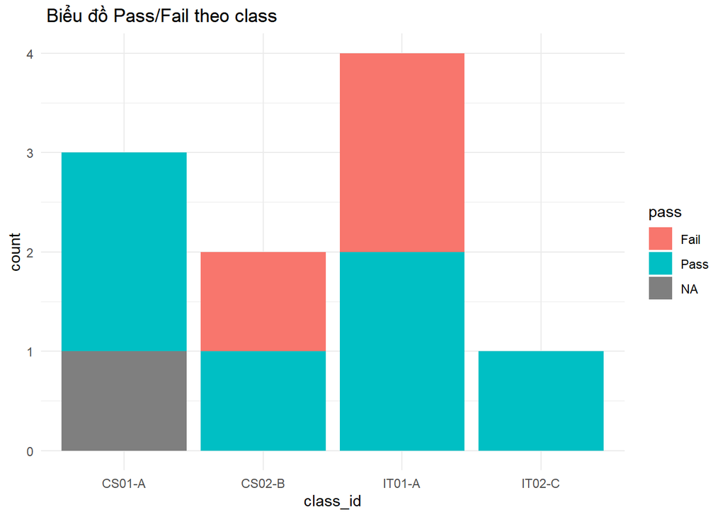

```r
ggplot(summary_class,aes(x=class_id,  y = count, fill=pass))+
  geom_bar(stat = "identity")+
  labs(
    title=" Biểu đồ Pass/Fail theo class",
    x="class_id",
    y="count",
  )+
  theme_minimal()
```

- Lớp IT02-c là nhóm duy nhất đạt 100% Pass trong bảng dữ liệu. Lớp CS01-A vì có 1 trường hợp NA nên không thể xác định là có đạt pass hay không.
- Lớp CS02-B và Lớp IT01-A có tỉ lệ Pass và Fail bằng nhau
- Sau khi làm sạch dữ liệu, dữ liệu được trực quan hóa để đánh giá số lượng sinh viên đạt chuẩn đầu ra và tỷ lệ học lại theo từng lớp. Qua biểu đồ có thể xác định lớp có tỷ lệ đạt cao hoặc nguy cơ học lại nhiều nhằm hỗ trợ công tác quản lý và dự báo trong giáo dục.

# 3. Dữ liệu bank

## 3.1 Làm sạch dữ liệu

### Kiểm tra giao dịch âm, giao dịch cực lớn và lỗi định dạng chi nhánh.

#### Chuyển dữ liệu thành dạng long

```r
bank_long <- banks %>%
  pivot_longer(
    cols=starts_with("X202"),
    names_to = "quarter",
    values_to="revenue"
  )
bank_long
```

```
## # A tibble: 48 × 4
##    product_code region quarter  revenue
##    <chr>        <chr>  <chr>      <int>
##  1 ELEC-TV      HCM    X2022_Q1     120
##  2 ELEC-TV      HCM    X2022_Q2     135
##  3 ELEC-TV      HCM    X2023_Q1     160
##  4 ELEC-TV      HCM    X2023_Q2     175
##  5 ELEC-TV      HN     X2022_Q1      95
##  6 ELEC-TV      HN     X2022_Q2     100
##  7 ELEC-TV      HN     X2023_Q1     110
##  8 ELEC-TV      HN     X2023_Q2     120
##  9 ELEC-TV      DN     X2022_Q1       0
## 10 ELEC-TV      DN     X2022_Q2     105
## # ℹ 38 more rows
```

#### Kiểm tra giao dịch

```r
bank_check <- bank_long %>%
  mutate(
    revenue_check = case_when(
      revenue < 0 ~ "Giao dịch âm",
      revenue > 1000 ~ "Giao dịch cực lớn",
      is.na(revenue) ~ "Thiếu dữ liệu",
      TRUE ~ "OK"
    ),

    region_check = case_when(
      !region %in% c("HCM","HN","DN") ~ "Sai định dạng chi nhánh",
      TRUE ~ "OK"
    )
  )
bank_check
```

```
## # A tibble: 48 × 6
##    product_code region quarter  revenue revenue_check region_check
##    <chr>        <chr>  <chr>      <int> <chr>         <chr>
##  1 ELEC-TV      HCM    X2022_Q1     120 OK            OK
##  2 ELEC-TV      HCM    X2022_Q2     135 OK            OK
##  3 ELEC-TV      HCM    X2023_Q1     160 OK            OK
##  4 ELEC-TV      HCM    X2023_Q2     175 OK            OK
##  5 ELEC-TV      HN     X2022_Q1      95 OK            OK
##  6 ELEC-TV      HN     X2022_Q2     100 OK            OK
##  7 ELEC-TV      HN     X2023_Q1     110 OK            OK
##  8 ELEC-TV      HN     X2023_Q2     120 OK            OK
##  9 ELEC-TV      DN     X2022_Q1       0 OK            OK
## 10 ELEC-TV      DN     X2022_Q2     105 OK            OK
## # ℹ 38 more rows
```

### Phân biệt outlier do khách hàng VIP với outlier do lỗi nhập liệu.

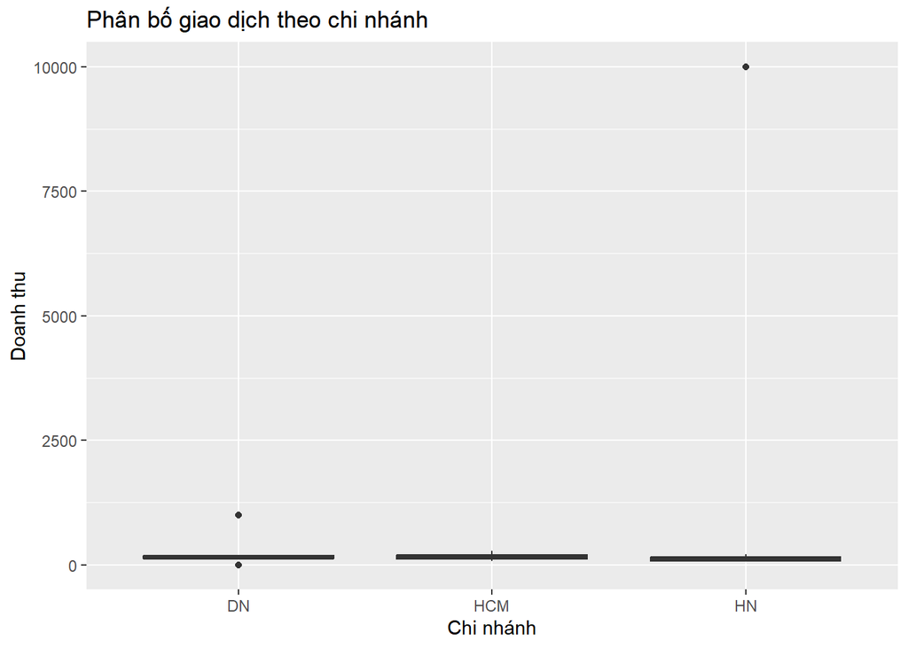

```r
ggplot(bank_long,aes(x = region, y = revenue)) +
  geom_boxplot() +
  labs(
    title = "Phân bố giao dịch theo chi nhánh",
    x = "Chi nhánh",
    y = "Doanh thu"
  )
```

### Kiểm tra missing values theo quý và theo phân khúc khách hàng.

#### Kiểm tả missing theo quý

```r
missing_quarter <- bank_long%>%
  group_by(quarter)%>%
  summarise(
    missing_quarter=sum(is.na(revenue))
  )
missing_quarter
```

```
## # A tibble: 4 × 2
##   quarter  missing_quarter
##   <chr>              <int>
## 1 X2022_Q1               0
## 2 X2022_Q2               2
## 3 X2023_Q1               0
## 4 X2023_Q2               0
```

#### Kiểm tả missing theo phân khúc khách hàng

```r
missing_product <- bank_long%>%
  group_by(product_code)%>%
  summarise(
    missing_product=sum(is.na(product_code))
  )
missing_product
```

```
## # A tibble: 4 × 2
##   product_code missing_product
##   <chr>                  <int>
## 1 ELEC-LAP                   0
## 2 ELEC-TV                    0
## 3 FASH-SHOE                  0
## 4 HOME-VAC                   0
```

### Chuẩn hóa các mã chi nhánh và phân khúc.

#### Chuẩn hóa mã chi nhánh

```r
bank_long <- bank_long %>%
  mutate(
    region = case_when(
      region %in% c("HOCHIMINH", "HCM", "TPHCM") ~ "HCM",

      region %in% c("HANOI", "HN") ~ "HN",
      TRUE ~ region
    )
  )
unique(bank_long$region)
```

```
## [1] "HCM" "HN"  "DN"
```

#### Chuẩn hóa phân khúc

```r
bank_long <- bank_long%>%
  mutate(
    product_code = toupper(product_code),
    product_code = trimws(product_code)
  )
unique(bank_long$product_code)
```

```
## [1] "ELEC-TV"   "ELEC-LAP"  "HOME-VAC"  "FASH-SHOE"
```

```r
bank_long
```

```
## # A tibble: 48 × 4
##    product_code region quarter  revenue
##    <chr>        <chr>  <chr>      <int>
##  1 ELEC-TV      HCM    X2022_Q1     120
##  2 ELEC-TV      HCM    X2022_Q2     135
##  3 ELEC-TV      HCM    X2023_Q1     160
##  4 ELEC-TV      HCM    X2023_Q2     175
##  5 ELEC-TV      HN     X2022_Q1      95
##  6 ELEC-TV      HN     X2022_Q2     100
##  7 ELEC-TV      HN     X2023_Q1     110
##  8 ELEC-TV      HN     X2023_Q2     120
##  9 ELEC-TV      DN     X2022_Q1       0
## 10 ELEC-TV      DN     X2022_Q2     105
## # ℹ 38 more rows
```

## 3.2 Xử lý dữ liệu và trực quan hóa

## Yêu cầu:

### 1. Chuyển dữ liệu theo tháng về long format.

Đã thực hiện ở trên

```r
View(bank_long)
```

### 2. Tạo biến month, branch, segment, transaction_value.

```r
bank_long <- bank_long%>%
  mutate(
    month=quarter,
    branch=region,
    segment=product_code,
    transaction_value=revenue)
bank_long
```

```
## # A tibble: 48 × 8
##    product_code region quarter  revenue month   branch segment transaction_value
##    <chr>        <chr>  <chr>      <int> <chr>   <chr>  <chr>               <int>
##  1 ELEC-TV      HCM    X2022_Q1     120 X2022_… HCM    ELEC-TV               120
##  2 ELEC-TV      HCM    X2022_Q2     135 X2022_… HCM    ELEC-TV               135
##  3 ELEC-TV      HCM    X2023_Q1     160 X2023_… HCM    ELEC-TV               160
##  4 ELEC-TV      HCM    X2023_Q2     175 X2023_… HCM    ELEC-TV               175
##  5 ELEC-TV      HN     X2022_Q1      95 X2022_… HN     ELEC-TV                95
##  6 ELEC-TV      HN     X2022_Q2     100 X2022_… HN     ELEC-TV               100
##  7 ELEC-TV      HN     X2023_Q1     110 X2023_… HN     ELEC-TV               110
##  8 ELEC-TV      HN     X2023_Q2     120 X2023_… HN     ELEC-TV               120
##  9 ELEC-TV      DN     X2022_Q1       0 X2022_… DN     ELEC-TV                 0
## 10 ELEC-TV      DN     X2022_Q2     105 X2022_… DN     ELEC-TV               105
## # ℹ 38 more rows
```

### 3. Tính các đặc trưng trễ như giá trị tháng trước, tăng trưởng tháng trước, rolling mean 2 hoặc 3 tháng.

```r
bank_features <- bank_long %>%
  arrange(branch, segment, month) %>%
  group_by(branch, segment) %>%
  mutate(
    gia_tri_ky_truoc = lag(transaction_value),
    tang_truong = transaction_value - gia_tri_ky_truoc
  )
bank_features <- bank_features %>%
  mutate(
    trung_binh_2_ky = rollmean(
      transaction_value,
      k = 2,
      fill = NA,
      align = "right"
    )
  )
bank_features
```

```
## # A tibble: 48 × 11
## # Groups:   branch, segment [10]
##    product_code region quarter  revenue month   branch segment transaction_value
##    <chr>        <chr>  <chr>      <int> <chr>   <chr>  <chr>               <int>
##  1 ELEC-TV      DN     X2022_Q1       0 X2022_… DN     ELEC-TV                 0
##  2 ELEC-TV      DN     X2022_Q2     105 X2022_… DN     ELEC-TV               105
##  3 ELEC-TV      DN     X2023_Q1     115 X2023_… DN     ELEC-TV               115
##  4 ELEC-TV      DN     X2023_Q2     130 X2023_… DN     ELEC-TV               130
##  5 FASH-SHOE    DN     X2022_Q1     128 X2022_… DN     FASH-S…               128
##  6 FASH-SHOE    DN     X2022_Q1     128 X2022_… DN     FASH-S…               128
##  7 FASH-SHOE    DN     X2022_Q2     999 X2022_… DN     FASH-S…               999
##  8 FASH-SHOE    DN     X2022_Q2     999 X2022_… DN     FASH-S…               999
##  9 FASH-SHOE    DN     X2023_Q1     160 X2023_… DN     FASH-S…               160
## 10 FASH-SHOE    DN     X2023_Q1     160 X2023_… DN     FASH-S…               160
## # ℹ 38 more rows
## # ℹ 3 more variables: gia_tri_ky_truoc <int>, tang_truong <int>,
## #   trung_binh_2_ky <dbl>
```

### 4. Xác định nhóm khách hàng đóng góp doanh thu cao nhưng biến động mạnh. Vẽ biểu đồ trực quan

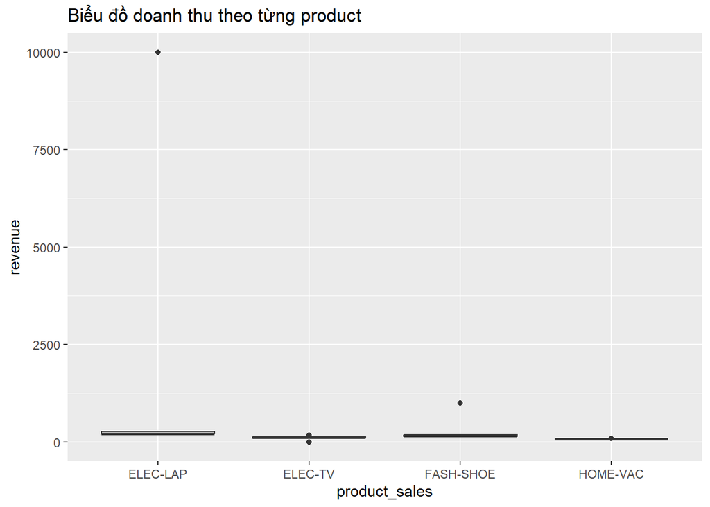

```r
ggplot(bank_long,aes(x=product_code,y=revenue))+
  geom_boxplot()+
  labs(
    title="Biểu đồ doanh thu theo từng product",
    x="product_sales",
    y="revenue"
  )
```

- Về quy mô doanh thu trung vị: Các nhóm ngành hàng có vị trí hộp nằm ở phân khúc phía trên của trục tung chứng tỏ mức doanh thu đạt được tốt và đều đặn hơn so với các nhóm ngành hàng nằm ở phía dưới.
- Về độ biến động và phân tán dữ liệu: Chiều dài thân hộp và độ dài của hai đường râu (Whiskers) khác nhau giữa các sản phẩm. Những sản phẩm có thân hộp dài chứng tỏ mức độ dao động doanh thu giữa các kỳ là khá lớn và chịu nhiều biến động từ thị trường. Ngược lại, những sản phẩm có thân hộp ngắn cho thấy doanh thu qua các kỳ tập trung ổn định quanh mức trung vị.
- Về các giá trị ngoại lai (Outliers): Biểu đồ ghi nhận sự xuất hiện của các điểm ngoại lai (chấm tròn) ở hầu hết các mã sản phẩm. Tuy nhiên, khoảng cách của các outlier này phân hóa thành hai xu hướng: một số sản phẩm có điểm ngoại lai nằm rất sát râu hộp, phản ánh các giao dịch đột biến lành mạnh và thực tế; trong khi đó, có những sản phẩm xuất hiện các điểm ngoại lai cực đoan nằm cách biệt hoàn toàn hẳn lên phía trên, đây là tín hiệu cần kiểm tra chéo để phát hiện lỗi hệ thống hoặc lỗi nhập liệu thủ công.

### 5. Đề xuất chiến lược kinh doanh dựa trên kết quả dự báo.

Hướng hành động chiến lược:

- Đẩy mạnh Marketing trọng điểm (Focus Strategy): Tập trung ngân sách marketing và các chương trình kích cầu vào ELEC TV và FASH-SHOE nhằm tối đa hóa doanh thu từ hai “mỏ neo” ổn định này.
- Khai thác phân khúc khách hàng VIP của ngành hàng: Thiết kế các chính sách ưu đãi đặc quyền dành riêng cho nhóm khách hàng tạo ra các giá trị ngoại lai (outliers) gần này để biến các giao dịch đột biến ngắn hạn thành nguồn thu định kỳ và bền vững cho doanh nghiệp.